```r
library(faraway)
library(ggplot2)
library(lmtest)
```

## Initial Data Analysis

```r
summary(chicago)
```

```
##       race            fire           theft             age
##  Min.   : 1.00   Min.   : 2.00   Min.   :  3.00   Min.   : 2.00
##  1st Qu.: 3.75   1st Qu.: 5.65   1st Qu.: 22.00   1st Qu.:48.60
##  Median :24.50   Median :10.40   Median : 29.00   Median :65.00
##  Mean   :34.99   Mean   :12.28   Mean   : 32.36   Mean   :60.33
##  3rd Qu.:57.65   3rd Qu.:16.05   3rd Qu.: 38.00   3rd Qu.:77.30
##  Max.   :99.70   Max.   :39.70   Max.   :147.00   Max.   :90.10
##      volact         involact          income
##  Min.   : 0.50   Min.   :0.0000   Min.   : 5583
##  1st Qu.: 3.10   1st Qu.:0.0000   1st Qu.: 8447
##  Median : 5.90   Median :0.4000   Median :10694
##  Mean   : 6.53   Mean   :0.6149   Mean   :10696
##  3rd Qu.: 9.65   3rd Qu.:0.9000   3rd Qu.:11989
##  Max.   :14.30   Max.   :2.2000   Max.   :21480
```

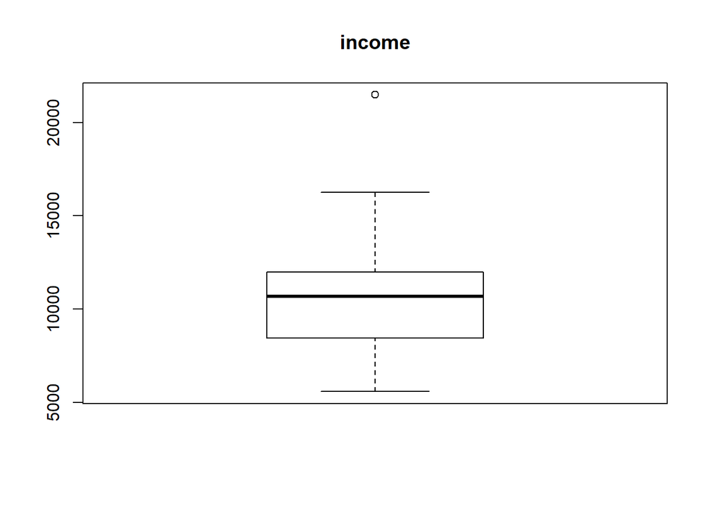

```r
boxplot(chicago[,7],main=names(chicago)[7])
```

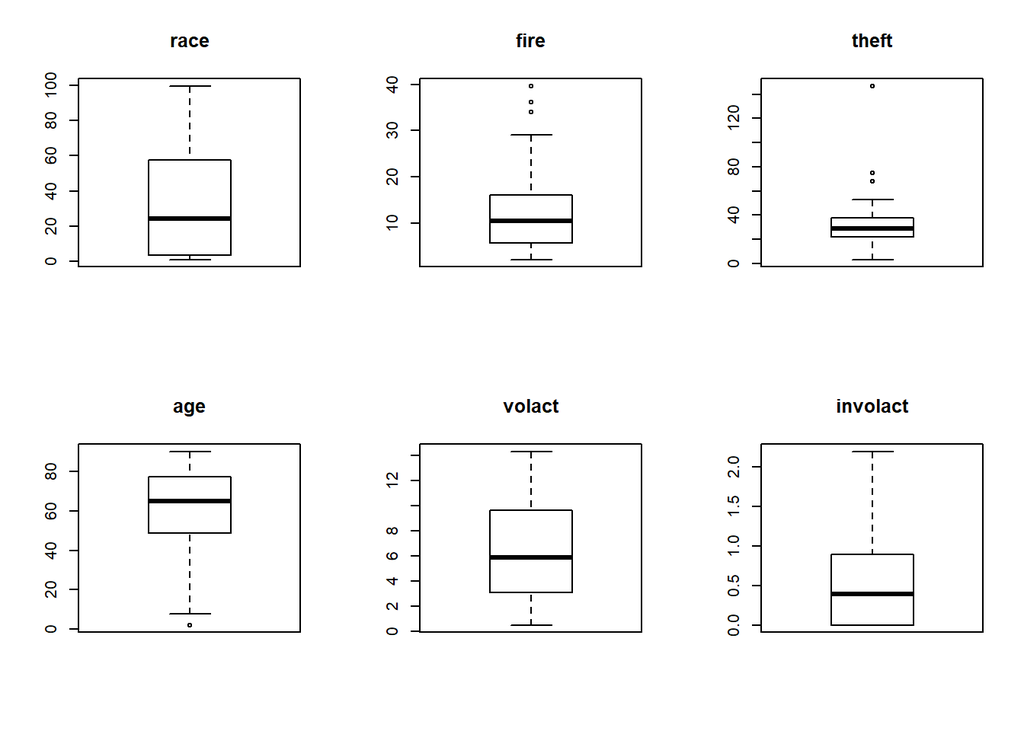

```r
par(mfrow=c(2,3))
for(i in 1:6)
  boxplot(chicago[,i],main=names(chicago)[i])
```

Income has much bigger numbers then other parameters. It would have greater weight in the regression model. Hence, to avoid this we standardize the data frame.

## Scaling

```r
ch = scale(chicago)
summary(ch)
```

```
##       race              fire             theft              age
##  Min.   :-1.0429   Min.   :-1.1050   Min.   :-1.3172   Min.   :-2.5837
##  1st Qu.:-0.9585   1st Qu.:-0.7126   1st Qu.:-0.4648   1st Qu.:-0.5195
##  Median :-0.3218   Median :-0.2020   Median :-0.1508   Median : 0.2070
##  Mean   : 0.0000   Mean   : 0.0000   Mean   : 0.0000   Mean   : 0.0000
##  3rd Qu.: 0.6955   3rd Qu.: 0.4054   3rd Qu.: 0.2529   3rd Qu.: 0.7518
##  Max.   : 1.9859   Max.   : 2.9478   Max.   : 5.1428   Max.   : 1.3188
##      volact           involact           income
##  Min.   :-1.5202   Min.   :-0.9701   Min.   :-1.856377
##  1st Qu.:-0.8647   1st Qu.:-0.9701   1st Qu.:-0.816510
##  Median :-0.1588   Median :-0.3390   Median :-0.000664
##  Mean   : 0.0000   Mean   : 0.0000   Mean   : 0.000000
##  3rd Qu.: 0.7866   3rd Qu.: 0.4498   3rd Qu.: 0.469527
##  Max.   : 1.9590   Max.   : 2.5009   Max.   : 3.915539
```

## Checking the liear Structure of the model

```r
ch= data.frame(ch)
```

```r
lmod_full <- lm(involact~., ch)
lmod_full$rank
```

```
## [1] 7
```

```r
summary(lmod_full)
```

```
##
## Call:
## lm(formula = involact ~ ., data = ch)
##
## Residuals:
##      Min       1Q   Median       3Q      Max
## -1.32997 -0.23055 -0.01589  0.29008  1.28167
##
## Coefficients:
##               Estimate Std. Error t value Pr(>|t|)
## (Intercept) -1.468e-16  7.795e-02   0.000 1.000000
## race         4.384e-01  1.472e-01   2.978 0.004911 **
## fire         5.545e-01  1.318e-01   4.206 0.000142 ***
## theft       -3.573e-01  1.023e-01  -3.494 0.001178 **
## age          2.712e-01  1.186e-01   2.287 0.027582 *
## volact      -6.370e-02  1.736e-01  -0.367 0.715519
## income       1.116e-01  1.399e-01   0.798 0.429759
## ---
## Signif. codes:  0 '***' 0.001 '**' 0.01 '*' 0.05 '.' 0.1 ' ' 1
##
## Residual standard error: 0.5344 on 40 degrees of freedom
## Multiple R-squared:  0.7517, Adjusted R-squared:  0.7144
## F-statistic: 20.18 on 6 and 40 DF,  p-value: 1.072e-10
```

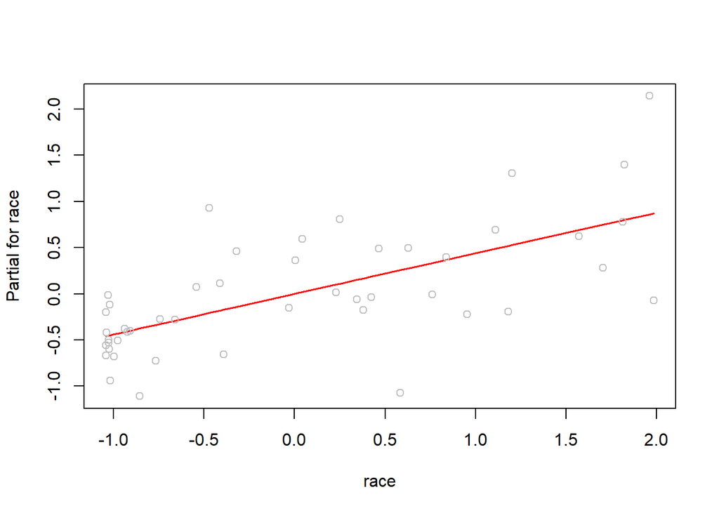

```r
termplot(lmod_full, partial.resid = T, terms=1)
```

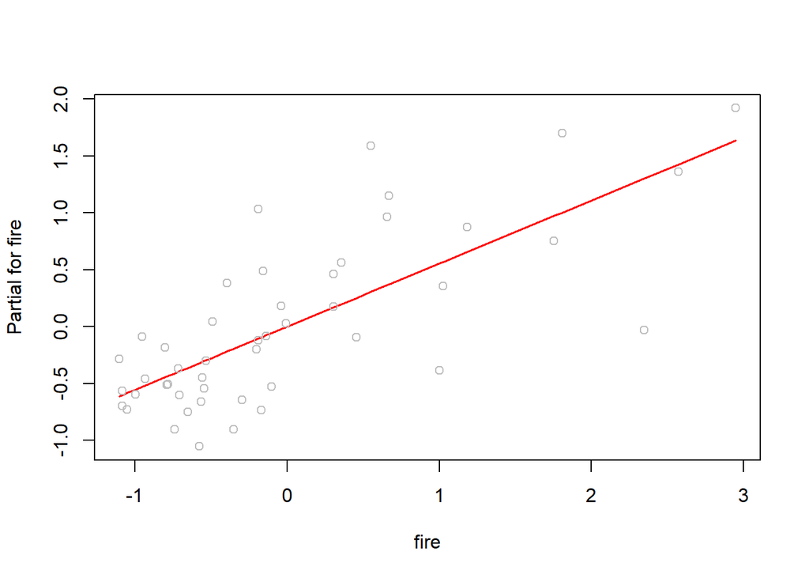

```r
termplot(lmod_full, partial.resid = T, terms=2)
```

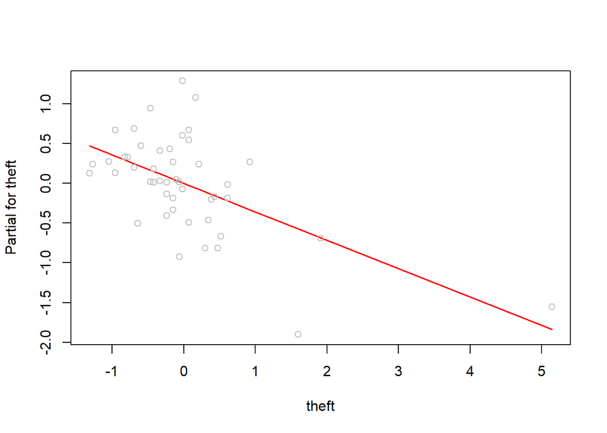

```r
termplot(lmod_full, partial.resid = T, terms=3)
```

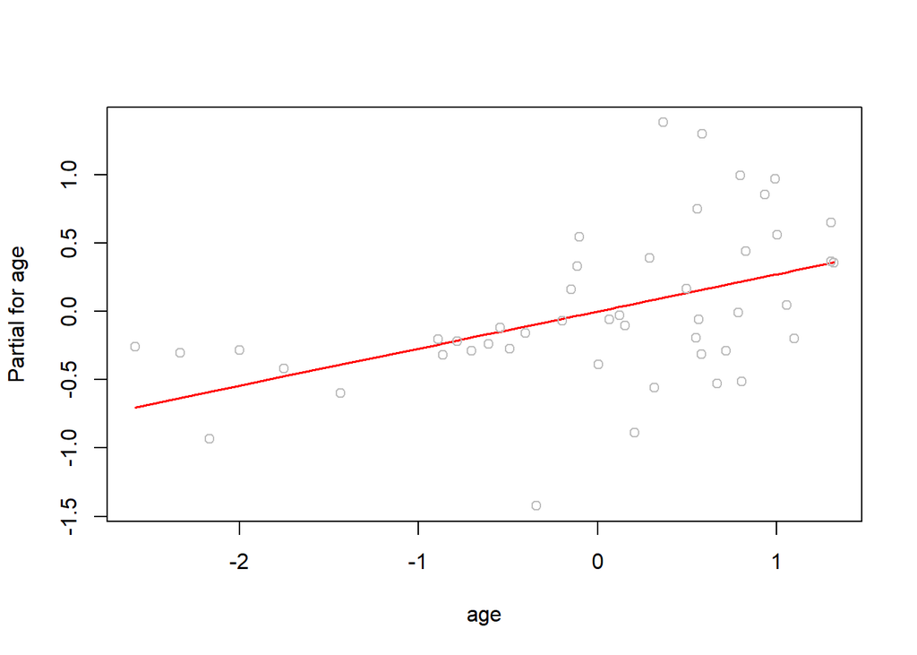

```r
termplot(lmod_full, partial.resid = T, terms=4)
```

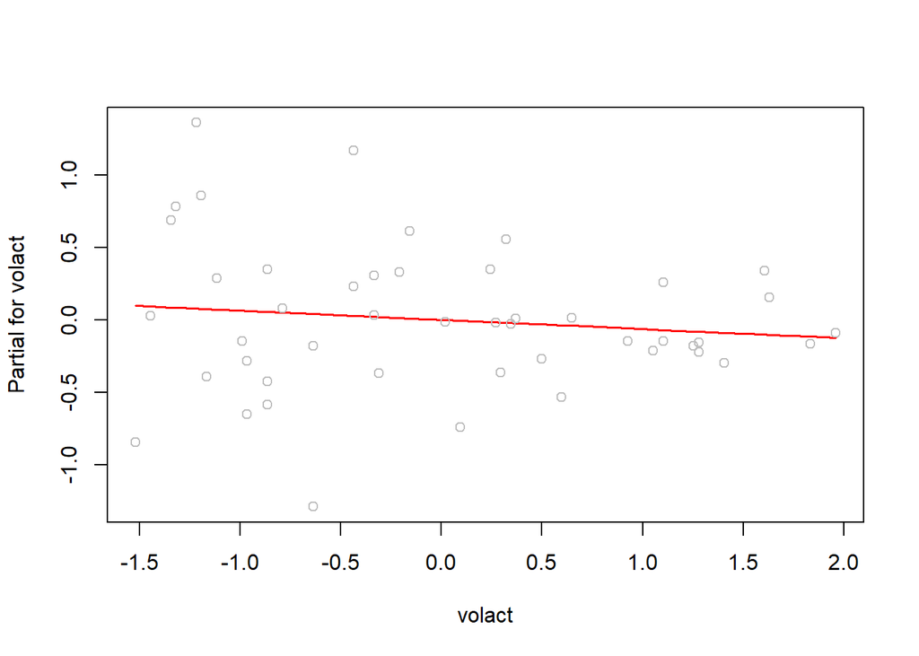

```r
termplot(lmod_full, partial.resid = T, terms=5)
```

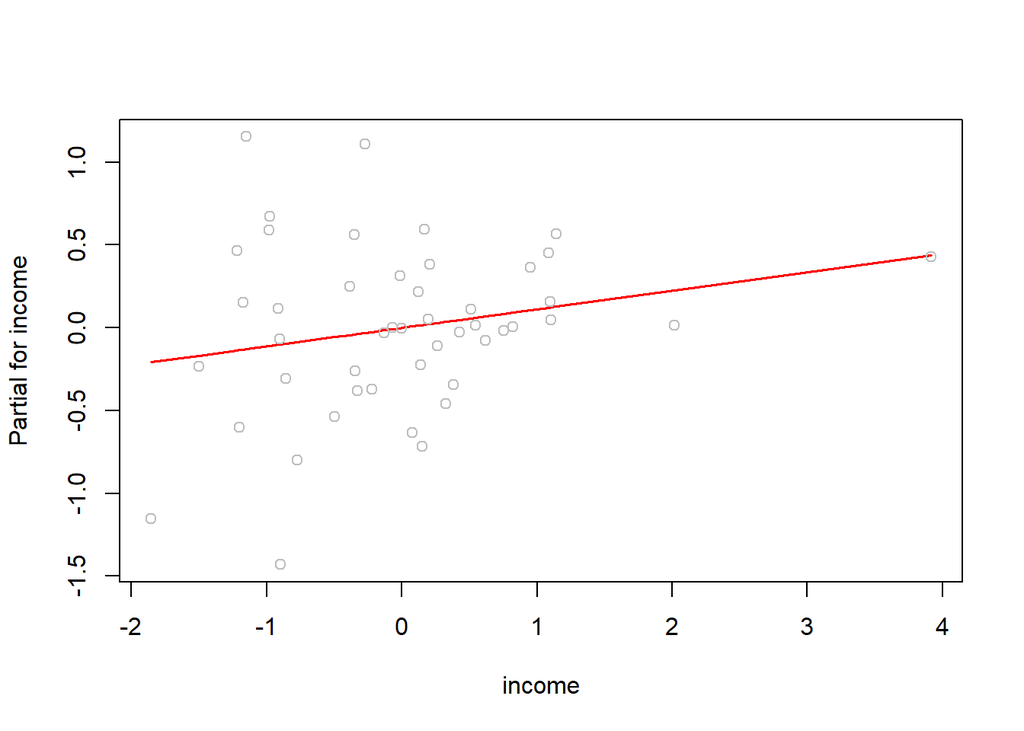

```r
termplot(lmod_full, partial.resid = T, terms=6)
```

Structure Seems Linear

## Checking Normality

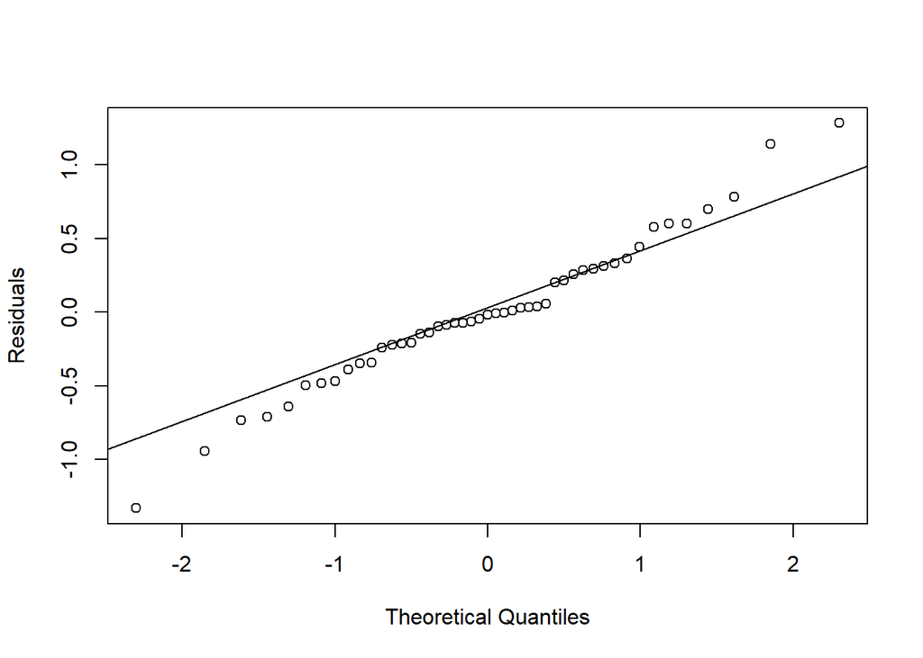

```r
qqnorm(residuals(lmod_full),ylab = "Residuals", main ="")
qqline(residuals(lmod_full))
```

It looks we have fatter tails problem  
Using Shapiro Test for varification.

```r
#Checking using Shapiro Test
  shapiro.test(residuals(lmod_full))
```

```
##
##  Shapiro-Wilk normality test
##
## data:  residuals(lmod_full)
## W = 0.98095, p-value = 0.6317
```

P-value High, Accepting NUll hypotheses. Dist is Normal.

## Checking Error Variance

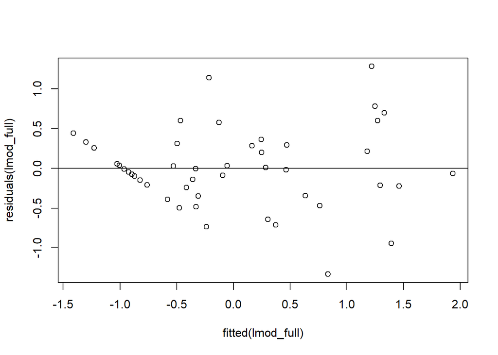

```r
plot(fitted(lmod_full),residuals(lmod_full))
abline(h=0)
```

Looks constant varrience with few anaomles.

## Checking Collinearity

```r
X = model.matrix(lmod_full)[,-1]
cor(X)
```

```
##              race       fire      theft        age     volact     income
## race    1.0000000  0.5927956  0.2550647  0.2505118 -0.7594196 -0.7037328
## fire    0.5927956  1.0000000  0.5562105  0.4122225 -0.6864766 -0.6104481
## theft   0.2550647  0.5562105  1.0000000  0.3176308 -0.3116183 -0.1729226
## age     0.2505118  0.4122225  0.3176308  1.0000000 -0.6057428 -0.5286695
## volact -0.7594196 -0.6864766 -0.3116183 -0.6057428  1.0000000  0.7509780
## income -0.7037328 -0.6104481 -0.1729226 -0.5286695  0.7509780  1.0000000
```

```r
vif(X)
```

```
##     race     fire    theft      age   volact   income
## 3.491088 2.798840 1.684571 2.266203 4.851903 3.153110
```

Every Predictor is under 5. we are safe. (volcat has relatively high correlection with other predictors  
Building model without volact

```r
lmod1_without_volcat = lm(involact ~  race + fire + theft + age + income, ch )
summary(lmod1_without_volcat)
```

```
##
## Call:
## lm(formula = involact ~ race + fire + theft + age + income, data = ch)
##
## Residuals:
##      Min       1Q   Median       3Q      Max
## -1.33205 -0.24935 -0.06458  0.28582  1.27524
##
## Coefficients:
##               Estimate Std. Error t value Pr(>|t|)
## (Intercept) -1.492e-16  7.712e-02   0.000 1.000000
## race         4.695e-01  1.191e-01   3.944 0.000307 ***
## fire         5.697e-01  1.238e-01   4.602    4e-05 ***
## theft       -3.622e-01  1.003e-01  -3.610 0.000827 ***
## age          2.946e-01  9.907e-02   2.973 0.004914 **
## income       1.065e-01  1.377e-01   0.773 0.443982
## ---
## Signif. codes:  0 '***' 0.001 '**' 0.01 '*' 0.05 '.' 0.1 ' ' 1
##
## Residual standard error: 0.5287 on 41 degrees of freedom
## Multiple R-squared:  0.7508, Adjusted R-squared:  0.7204
## F-statistic: 24.71 on 5 and 41 DF,  p-value: 2.159e-11
```

Model without volcat performs better.  
Now, Checking this using anova.

```r
anova(lmod1_without_volcat,lmod_full)
```

```
## Analysis of Variance Table
##
## Model 1: involact ~ race + fire + theft + age + income
## Model 2: involact ~ race + fire + theft + age + volact + income
##   Res.Df    RSS Df Sum of Sq      F Pr(>F)
## 1     41 11.462
## 2     40 11.424  1  0.038476 0.1347 0.7155
```

H0: Beta(r) = 0  
H1: Beta(r) != 0  
High p-value accept Null Hyptoses.  
simpl words: volcat is not significat.  
Cheking Summry of the model

```r
summary(lmod1_without_volcat)
```

```
##
## Call:
## lm(formula = involact ~ race + fire + theft + age + income, data = ch)
##
## Residuals:
##      Min       1Q   Median       3Q      Max
## -1.33205 -0.24935 -0.06458  0.28582  1.27524
##
## Coefficients:
##               Estimate Std. Error t value Pr(>|t|)
## (Intercept) -1.492e-16  7.712e-02   0.000 1.000000
## race         4.695e-01  1.191e-01   3.944 0.000307 ***
## fire         5.697e-01  1.238e-01   4.602    4e-05 ***
## theft       -3.622e-01  1.003e-01  -3.610 0.000827 ***
## age          2.946e-01  9.907e-02   2.973 0.004914 **
## income       1.065e-01  1.377e-01   0.773 0.443982
## ---
## Signif. codes:  0 '***' 0.001 '**' 0.01 '*' 0.05 '.' 0.1 ' ' 1
##
## Residual standard error: 0.5287 on 41 degrees of freedom
## Multiple R-squared:  0.7508, Adjusted R-squared:  0.7204
## F-statistic: 24.71 on 5 and 41 DF,  p-value: 2.159e-11
```

P-value of income is high. means it insignoficant.  
Lets try removing income.

```r
lmod2_without_volcat_income = lm(involact ~ race + fire + theft + age, ch)
summary(lmod2_without_volcat_income)
```

```
##
## Call:
## lm(formula = involact ~ race + fire + theft + age, data = ch)
##
## Residuals:
##      Min       1Q   Median       3Q      Max
## -1.37433 -0.23398 -0.03094  0.31505  1.28802
##
## Coefficients:
##               Estimate Std. Error t value Pr(>|t|)
## (Intercept) -1.506e-16  7.675e-02   0.000 1.000000
## race         4.166e-01  9.696e-02   4.297 0.000100 ***
## fire         5.378e-01  1.162e-01   4.629 3.51e-05 ***
## theft       -3.374e-01  9.461e-02  -3.566 0.000921 ***
## age          2.568e-01  8.576e-02   2.994 0.004595 **
## ---
## Signif. codes:  0 '***' 0.001 '**' 0.01 '*' 0.05 '.' 0.1 ' ' 1
##
## Residual standard error: 0.5262 on 42 degrees of freedom
## Multiple R-squared:  0.7472, Adjusted R-squared:  0.7231
## F-statistic: 31.03 on 4 and 42 DF,  p-value: 4.799e-12
```

Removing it does not make much of the difference  
Comparing 2 model using anova

```r
anova(lmod2_without_volcat_income,lmod1_without_volcat)
```

```
## Analysis of Variance Table
##
## Model 1: involact ~ race + fire + theft + age
## Model 2: involact ~ race + fire + theft + age + income
##   Res.Df    RSS Df Sum of Sq      F Pr(>F)
## 1     42 11.629
## 2     41 11.462  1   0.16703 0.5975  0.444
```

H0: Beta(r) = 0  
H1: Beta(r) != 0  
Significane level = 5%  
High p-value accept Null Hyptoses.  
simple words: income is not significat.

## Checking Unusual Observations

### Checking Leverage Points

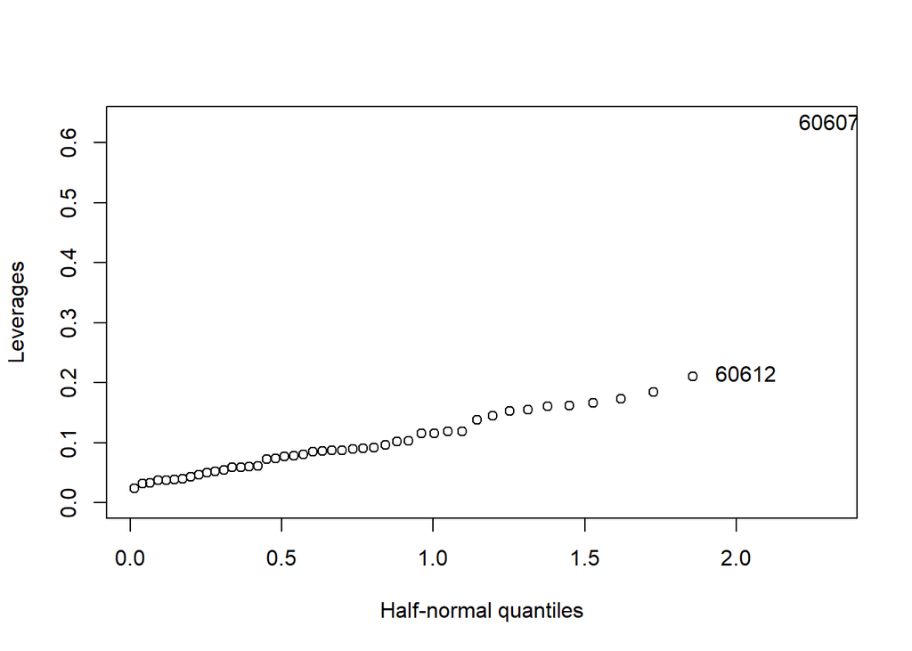

```r
zips = row.names(ch)
hat_vals = hatvalues(lmod2_without_volcat_income)
halfnorm(hat_vals,labs = zips, ylab = "Leverages")
```

Zip Code: 60607 seems to be high leverage points.  
Cheking these observations

```r
row1 = which(rownames(ch) == 60607)
ch[row1,]
```

```
##            race     fire   theft      age     volact  involact    income
## 60607 0.4668919 2.947806 5.14281 1.004313 -0.3352558 0.4498212 -1.175235
```

We can observe high theft in this observations  
See what’s happens if we remove this overvations.

```r
lmod3_modified_1 = lm(involact ~ race + fire + theft + age ,ch[-row1])
summary(lmod3_modified_1)
```

```
##
## Call:
## lm(formula = involact ~ race + fire + theft + age, data = ch[-row1])
##
## Residuals:
##      Min       1Q   Median       3Q      Max
## -1.37433 -0.23398 -0.03094  0.31505  1.28802
##
## Coefficients:
##               Estimate Std. Error t value Pr(>|t|)
## (Intercept) -1.506e-16  7.675e-02   0.000 1.000000
## race         4.166e-01  9.696e-02   4.297 0.000100 ***
## fire         5.378e-01  1.162e-01   4.629 3.51e-05 ***
## theft       -3.374e-01  9.461e-02  -3.566 0.000921 ***
## age          2.568e-01  8.576e-02   2.994 0.004595 **
## ---
## Signif. codes:  0 '***' 0.001 '**' 0.01 '*' 0.05 '.' 0.1 ' ' 1
##
## Residual standard error: 0.5262 on 42 degrees of freedom
## Multiple R-squared:  0.7472, Adjusted R-squared:  0.7231
## F-statistic: 31.03 on 4 and 42 DF,  p-value: 4.799e-12
```

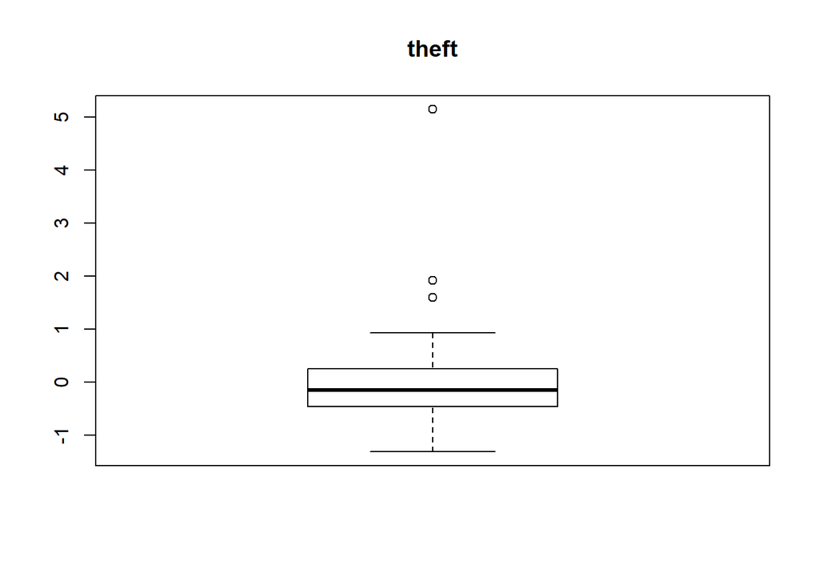

```r
theft = 3
boxplot(ch[,theft],main=names(ch)[theft])
```

This observation theft value is far higer then other observation. it must be reported.

## Checking Outliers

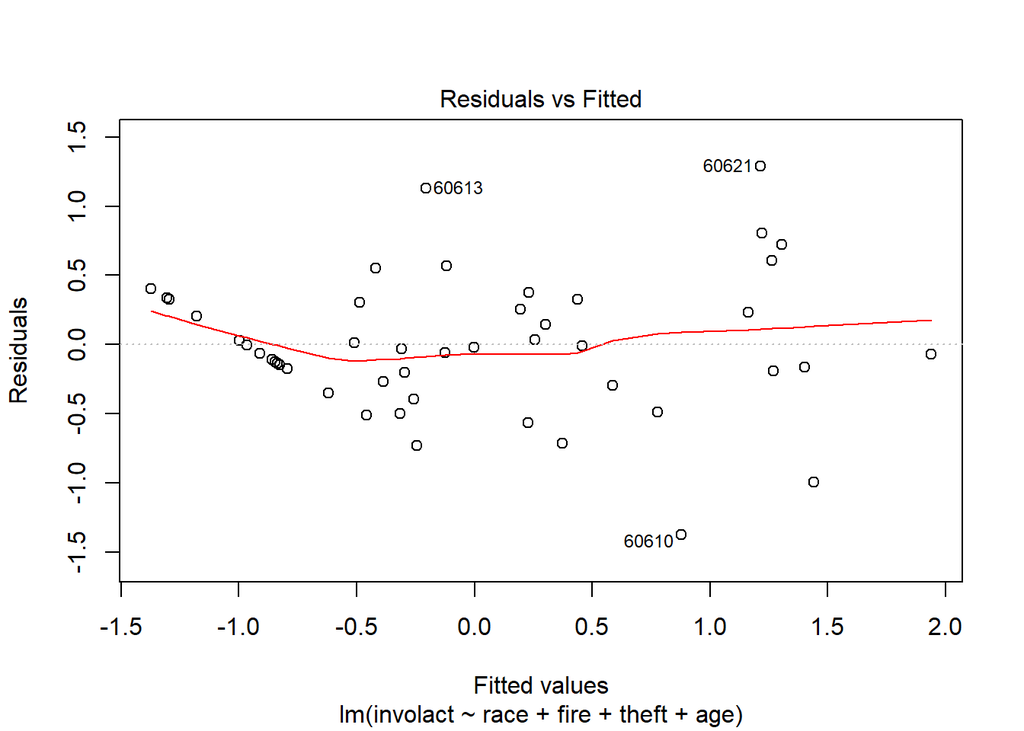

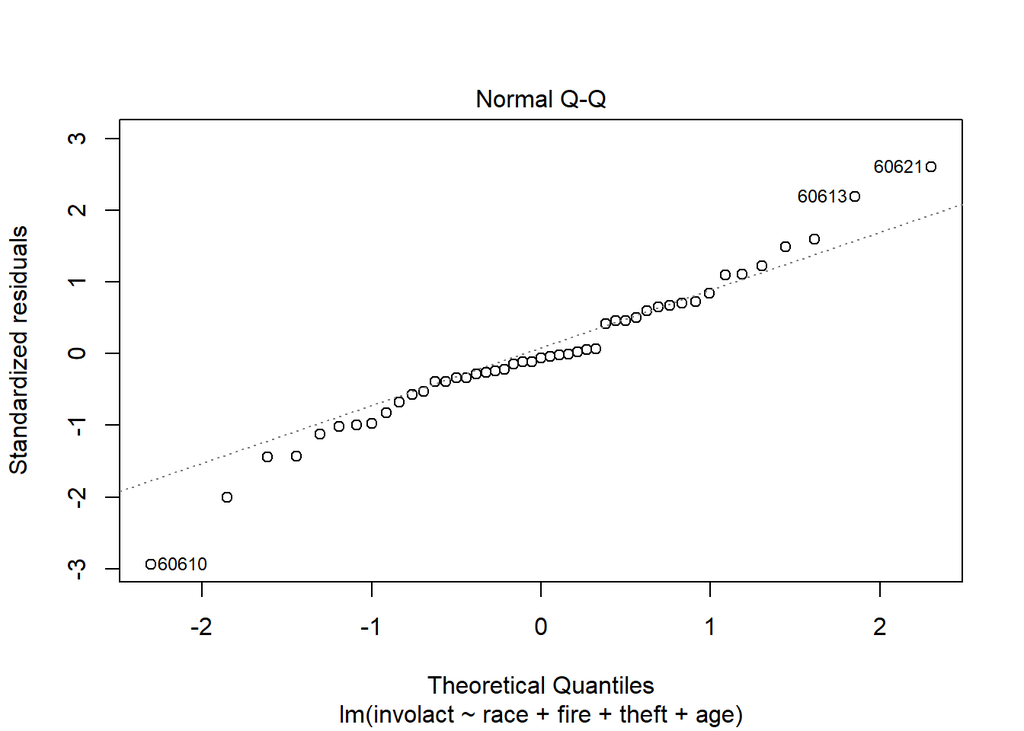

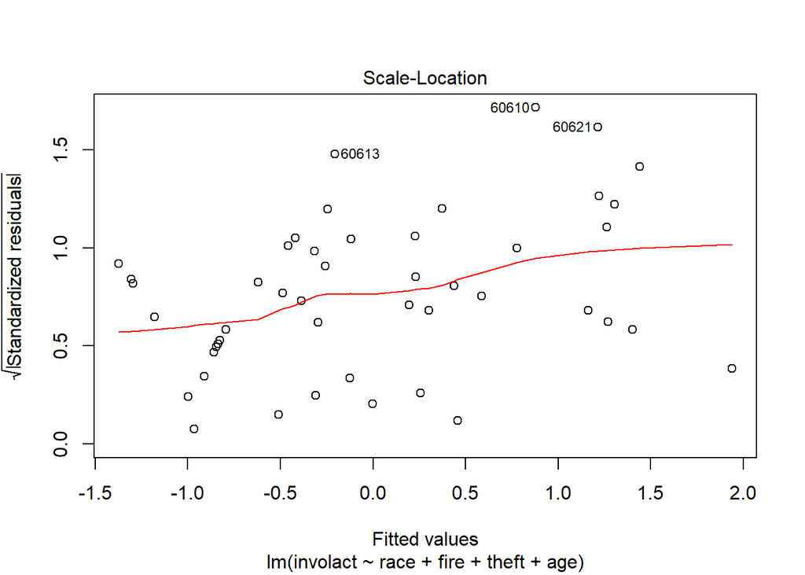

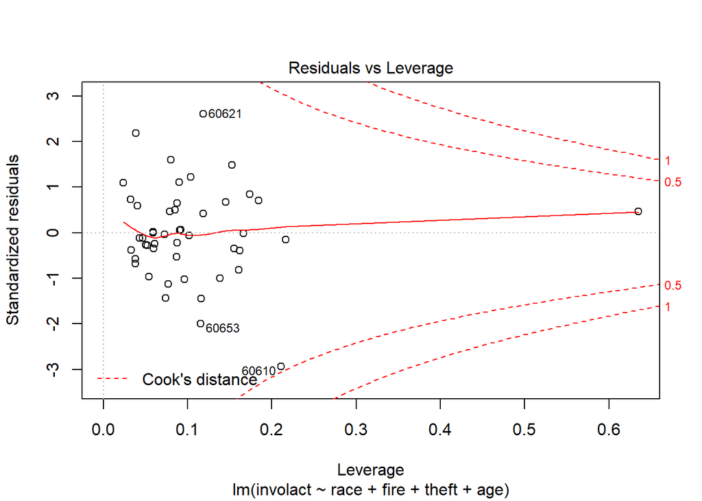

```r
plot(lmod2_without_volcat_income)
```

Cooks distance doesnot show any evidence of any outlier. However one point could possible an outlier  
Checking using Stundtized residuals

```r
stud=rstudent(lmod2_without_volcat_income)
tt=stud[which.max(abs(stud))]
#Pvalue calculation
n = nrow(ch)
p = length(coef(lmod2_without_volcat_income))
print('Zip(observation) and P-value')
```

```
## [1] "Zip(observation) and P-value"
```

```r
2*(1-pt(abs(tt),n-p-1))
```

```
##       60610
## 0.002247299
```

```r
print("Alpha2")
```

```
## [1] "Alpha2"
```

```r
(alpha2 = 0.5/n)
```

```
## [1] 0.0106383
```

```r
row1 = which(rownames(ch) == 60610)
ch[row1,]
```

```
##            race     fire    theft       age     volact   involact     income
## 60610 0.5835006 2.345802 1.598776 -0.342311 -0.6377906 -0.4968174 -0.8949356
```

It seems we have high fire value in this observation.

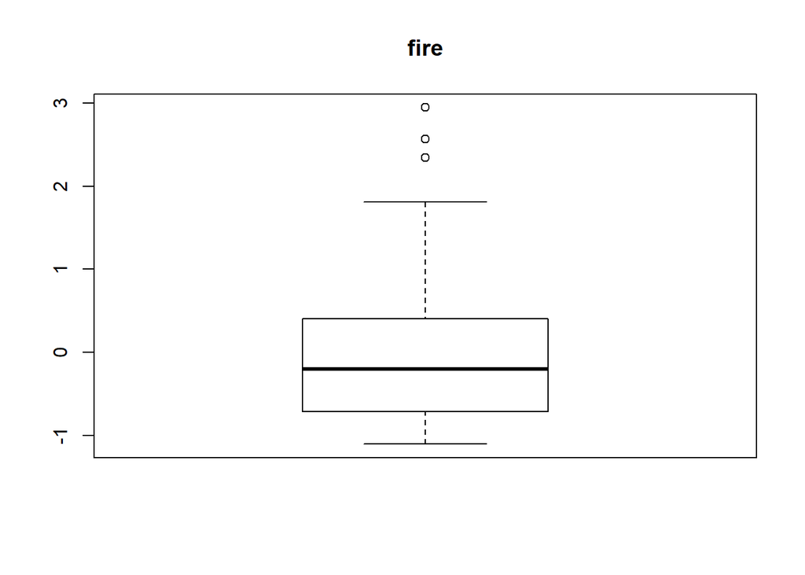

```r
fire = 2
boxplot(ch[,fire],main=names(ch)[fire])
```

We can see cluster of outliers  
lets Investigate and get these clustor

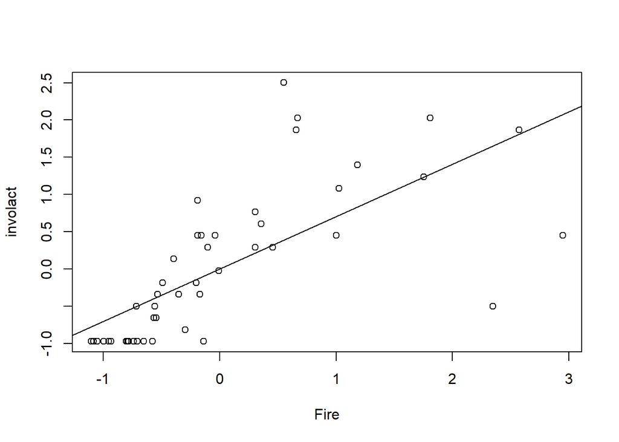

```r
plot(involact~fire,ch,xlab="Fire", ylab = "involact")
lmod_dummy = lm(involact~fire,ch)
abline(lmod_dummy)
```

```r
#Beforni_Corection
qt(1-(.05/(47*2)),47-2-1)
```

```
## [1] 3.504708
```

```r
range(rstudent(lmod2_without_volcat_income))
```

```
## [1] -3.259645  2.813745
```

```r
#lmod_dummy2 = lm(involact ~ fire, ch, subset = (fire>3.5))
```